# HopSkipDrive Documentation

Mike Brucek

2024-07-15

# Overall Recommendation

The solution to optimizing boost rates with respect to overall price requires a nuanced approach that combines predictive modeling, linear optimization, and an understanding of driver psychology.

The first step involves predicting the final price of a ride using the initial feature set. This prediction, with consideration of the error margins, will help define a search space for calibrating various charges, including boost rate. This step sets the groundwork for further optimization, ensuring that all factors affecting the total price are taken into account. More simply stated, this step helps define the constraints for a linear optimization approach.

Applying a linear optimization function to this predicted search space is the recommended approach. Linear optimization is a mathematical technique used to find the best outcome in a given model by maximizing or minimizing a specific outcome, subject to a set of linear constraints. In our case, we can aim to minimize the boost rate within the predictive window potential rates from the earlier step. Constraints could be a number of factors, such as time to claim and total price.

We should attempt to prevent drivers from recognizing and exploiting patterns by incorporating a level of randomness into the final model or models. This randomness would not be arbitrary, but strategically designed to maintain the effectiveness of the boost strategy, ensuring that drivers remain engaged and responsive to the changes. We should consider adding randomness and/or controls in three specific ways: the step in the boost sequence, the time lapse between boosts, and the amount.

Evaluating individual drivers and their tendencies is another key aspect. Some drivers may react more favorably to boost decreases compared to others. When drivers who accept boost offers at the first sign of decrease should be noted. When these drivers are more present in the driver pool, the likelihood of implementing boost decreases should be higher. Conversely, with a pool dominated by less predictable drivers, the focus should shift to adjusting the boost amount upward rather than focus on its polarity. This tailored approach ensures that the Boost strategy is adaptable to the varying behaviors within the driver pool.

This multifaceted approach combines predictive modeling, strategic randomness, and driver-specific insights to optimize the boost process and decrease the time to a claimed ride, all while respecting the desire to minimize the total price.

## Executive Summary: Exploratory Analysis

These points are the key takeaways from the process. Code and commentary are repeated in the Knowledge Transfer section of this documentation.

### General Exploration

- No missing values
- Two timestamp elements that may need to be reshaped for later use
- Location is the only character element
- The “total price” appears to be greater than the “base_plus_boost”, suggesting there is some sort of hidden fee
  - The hidden charge doesn’t kick in until after the 2nd boost

**Next Steps:**

- Create elements that allow us to explore the hidden fees
- Create elements that reveal how the various fees evolve throughout the boosting process

### Location

- Trips appear to be broken out uniformly across locations
- The average number of boosts seems uniform across locations
- The average costs has very little fluctuation between markets

### Modeling

Three independent models were created for testing and experimentation - two ML models and a basic linear optimization model. Given time constraints and the intention to discuss this documentation in a live setting, I am providing code for what was completed in the Knowledge Transfer section with the intention of explaining and summarizing in conversation. Any notes related to the reasoning for taking the approach will be provided there as well.

# Knowledge Transfer - Exploratory Analysis

## Data Setup

For ease of reading, these steps are presented in a single block for review, despite each data frame being created on demand as the EDA process called for new perspectives.

```r
library(tidyverse)
library(reshape2) # for melt
library(janitor)  # for adorned rows

setwd("C:\\Users\\MichaelBrucek\\Desktop\\HSD Task")



# Read and Explore Data ----
data = read.csv("boost_df.csv")


# Convert data types for ease of use
data$timestamp = lubridate::as_datetime(data$timestamp)
data$trip_start_date = lubridate::as_datetime(data$trip_start_date)



# Add elements that help understand the data ----
data_2 = data %>%
  mutate(hidden_charges = total_price - base_plus_boost,  # Reveal hidden charges (base + boost does not always == total_price)
         hours_from_boost_to_ride = as.numeric(trip_start_date - timestamp) * 24) %>%  #Understand the lapse between the boost dates and the strip_start_date
  # reorder for easier interpretation
  select(c(trip_id, metro_area, trip_start_date, timestamp, hours_from_boost_to_ride,
           boost_number, base_price, boost_amount, base_plus_boost, base_plus_boost,
           hidden_charges, total_price, claimed, total_driver_supply))




## Explore Trips ----
trip_summary = data_2 %>%
  group_by(trip_id) %>%
  summarise(metro_area = max(metro_area),
            number_of_boosts = n() - 1,
            unclaimed_trip = ifelse(sum(claimed)==0, 1, 0),
            starting_rate = min(total_price),
            ending_rate = max(total_price),
            total_price_change = ending_rate - starting_rate,
            total_drives_when_claimed = ifelse(max(claimed) == 1,
                                               total_driver_supply[claimed==1],
                                               total_driver_supply)
  )


# Add percentage increase stats to better understand how these elements move together
data_3 = data_2 %>%
  group_by(trip_id) %>%
  mutate(
    boost_amount_pct_of_total = (boost_amount / total_price) * 100,
    boost_pct_increase = ifelse(boost_number < 2, 0, (boost_amount - lag(boost_amount)) / lag(boost_amount) * 100),
    boost_pct_increase = ifelse(is.na(boost_pct_increase), 0, boost_pct_increase),
       # Hidden charge doesn't kick in until after the 2nd boost
    hidden_charge_pct_of_total = (hidden_charges / total_price) * 100,
    hidden_charge_pct_increase = ifelse(boost_number < 3, 0, (hidden_charges - lag(hidden_charges)) / lag(hidden_charges) * 100),
    hidden_charge_pct_increase = ifelse(is.na(hidden_charge_pct_increase), 0, hidden_charge_pct_increase)
  ) %>%
  select(c(trip_id, metro_area, trip_start_date, timestamp, hours_from_boost_to_ride,
           boost_number, base_price, boost_amount, boost_pct_increase, boost_amount_pct_of_total,
           base_plus_boost, base_plus_boost, hidden_charges, hidden_charge_pct_increase, hidden_charge_pct_of_total,
           total_price, claimed, total_driver_supply))
```

## Genreral Exploration

```r
str(data)
```

```
## 'data.frame':    119835 obs. of  11 variables:
##  $ trip_id            : int  1 1 1 1 2 2 2 2 2 2 ...
##  $ timestamp          : POSIXct, format: "2022-12-30 12:00:00" "2022-12-30 12:05:00" ...
##  $ boost_number       : int  0 1 2 3 0 1 2 3 4 5 ...
##  $ boost_amount       : num  0 1.76 2.04 1.78 0 1.61 1.74 1.74 1.68 1.67 ...
##  $ base_plus_boost    : num  10 11.8 12 11.8 35 ...
##  $ claimed            : int  0 0 0 1 0 0 0 0 0 0 ...
##  $ total_price        : num  10 11.8 13.8 15.6 35 ...
##  $ base_price         : num  10 10 10 10 35 35 35 35 35 35 ...
##  $ total_driver_supply: int  202 263 203 201 242 348 261 303 354 248 ...
##  $ metro_area         : chr  "SFO" "SFO" "SFO" "SFO" ...
##  $ trip_start_date    : POSIXct, format: "2023-01-01 00:00:00" "2023-01-01 00:00:00" ...
```

```r
summary(data)
```

```
##     trip_id        timestamp                       boost_number
##  Min.   :    1   Min.   :2022-12-30 12:00:00.00   Min.   : 0.000
##  1st Qu.: 4994   1st Qu.:2023-07-26 13:47:30.00   1st Qu.: 1.000
##  Median :10014   Median :2024-02-20 17:15:00.00   Median : 3.000
##  Mean   :10008   Mean   :2024-02-20 11:40:48.52   Mean   : 3.334
##  3rd Qu.:15043   3rd Qu.:2024-09-17 06:17:30.00   3rd Qu.: 5.000
##  Max.   :20000   Max.   :2025-04-11 19:15:00.00   Max.   :10.000
##   boost_amount   base_plus_boost    claimed        total_price
##  Min.   :0.000   Min.   :10.00   Min.   :0.0000   Min.   :10.00
##  1st Qu.:1.600   1st Qu.:13.94   1st Qu.:0.0000   1st Qu.:17.67
##  Median :1.740   Median :17.77   Median :0.0000   Median :25.28
##  Mean   :1.561   Mean   :24.63   Mean   :0.1512   Mean   :29.32
##  3rd Qu.:1.930   3rd Qu.:36.61   3rd Qu.:0.0000   3rd Qu.:38.56
##  Max.   :7.120   Max.   :54.78   Max.   :1.0000   Max.   :72.34
##    base_price    total_driver_supply  metro_area
##  Min.   :10.00   Min.   : 72.0       Length:119835
##  1st Qu.:12.00   1st Qu.:126.0       Class :character
##  Median :16.00   Median :166.0       Mode  :character
##  Mean   :23.07   Mean   :210.2
##  3rd Qu.:35.00   3rd Qu.:222.0
##  Max.   :48.50   Max.   :899.0
##  trip_start_date
##  Min.   :2023-01-01 00:00:00.00
##  1st Qu.:2023-07-28 01:00:00.00
##  Median :2024-02-22 05:00:00.00
##  Mean   :2024-02-21 23:24:08.41
##  3rd Qu.:2024-09-18 18:00:00.00
##  Max.   :2025-04-13 07:00:00.00
```

- No missing values
- Two Timestamp elements that may need to be reshaped for later use
- Location is the only character element
- The “total price” appears to be greater than the “base_plus_boost”, suggesting there is some sort of hidden fee
  - The hidden charge doesn’t kick in until after the 2nd boost

**Next Steps:**

- Add elements that allow us to explore the hidden fees
- Add elements that reveal how the various fees evolve throughout the boosting process

## Location Data EDA

Summary table of aggregated location data

```
## # A tibble: 14 × 6
##    metro_area total_trips avg_boosts avg_total_cost avg_driver_supply
##    <chr>            <int>      <dbl>          <dbl>             <dbl>
##  1 ATL               8558       6.73           34.2             298.
##  2 DEN               8392       6.66           35.8             150.
##  3 DET               9063       6.72           36.7             119.
##  4 DFW               8621       6.76           35.0             189.
##  5 LAS               8811       6.57           37.9              89.5
##  6 LAX               8230       6.63           33.5             745.
##  7 MCL               8832       6.70           36.7             130.
##  8 MSP               8315       6.62           35.3             179.
##  9 NYC               8493       6.62           35.2             249.
## 10 PDX               8721       6.67           36.6              99.3
## 11 SDF               8691       6.66           35.2             201.
## 12 SFO               8592       6.71           34.9             220.
## 13 STL               7918       6.56           35.4             139.
## 14 TPA               8598       6.72           35.3             160.
## # ℹ 1 more variable: avg_base_price <dbl>
```

- Trips appear to be broken out uniformly across locations
- The average number of boosts seems uniform across locations

The average costs has very little fluctuation between markets

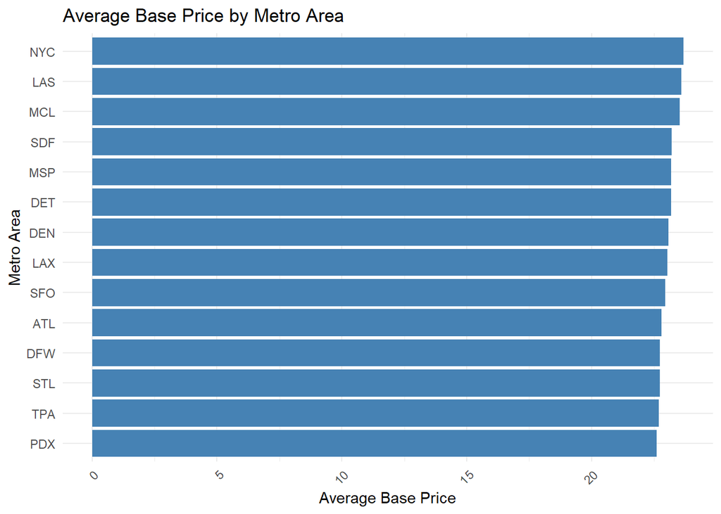

```r
 # Avg Base Price by Location
        ggplot(location_summary, aes(x = reorder(metro_area, avg_base_price), y = avg_base_price)) +
          geom_bar(stat = "identity", fill = "steelblue") +
          coord_flip() +
          labs(title = "Average Base Price by Metro Area",
               x = "Metro Area",
               y = "Average Base Price") +
          theme_minimal() +
          theme(axis.text.x = element_text(angle = 45, hjust = 1))
```

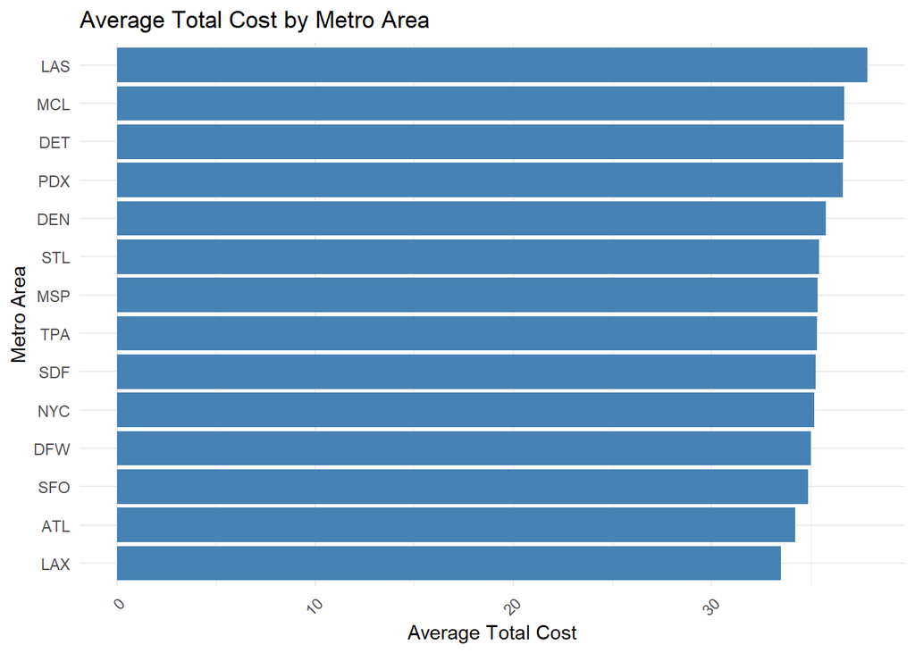

```r
        # Avg Final Cost by Location
        ggplot(location_summary, aes(x = reorder(metro_area, avg_total_cost), y = avg_total_cost)) +
          geom_bar(stat = "identity", fill = "steelblue") +
          coord_flip() +
          labs(title = "Average Total Cost by Metro Area",
               x = "Metro Area",
               y = "Average Total Cost") +
          theme_minimal() +
          theme(axis.text.x = element_text(angle = 45, hjust = 1))
```

The average driver supply has a decent amount of variance based on location

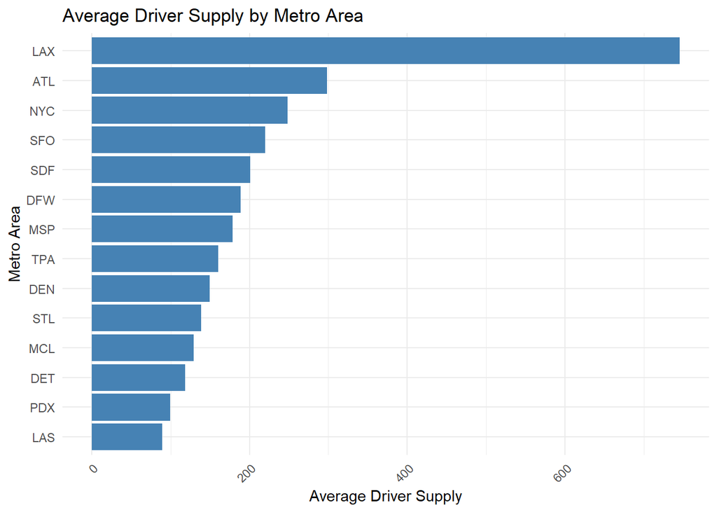

```r
          # Driver Supply by Location
          ggplot(location_summary, aes(x = reorder(metro_area, avg_driver_supply), y = avg_driver_supply)) +
            geom_bar(stat = "identity", fill = "steelblue") +
            coord_flip() +
            labs(title = "Average Driver Supply by Metro Area",
                 x = "Metro Area",
                 y = "Average Driver Supply") +
            theme_minimal() +
            theme(axis.text.x = element_text(angle = 45, hjust = 1))
```

The correlation in average driver supply and average total cost by metro area is fairly strong

```r
         # correlation of cost and location
          cor(location_summary$avg_driver_supply, location_summary$avg_total_cost)
```

```
## [1] -0.754063
```

## Boost Data EDA

How many trips are in each boost count category?

```r
# How many trips are in each boost count category?
boost_count_summary_per_trip = trip_summary %>%
  group_by(number_of_boosts) %>%
  summarise(unique_trips = length(unique(trip_id)),
            claimed_trips = sum(unclaimed_trip==0),
            unclaimed_trips = sum(unclaimed_trip),
            avg_starting_rate = mean(starting_rate),
            avg_ending_rate = mean(ending_rate),
            avg_price_change = mean(total_price_change),
            avg_drivers_at_claim = mean(total_drives_when_claimed)
  )


print(boost_count_summary_per_trip, n=15)
```

```
## # A tibble: 11 × 8
##    number_of_boosts unique_trips claimed_trips unclaimed_trips avg_starting_rate
##               <dbl>        <int>         <int>           <dbl>             <dbl>
##  1                0         1878             0            1878              23.6
##  2                1         1791          1791               0              22.9
##  3                2         1790          1790               0              22.3
##  4                3         1846          1846               0              23.1
##  5                4         1811          1811               0              23.5
##  6                5         1798          1798               0              22.8
##  7                6         1813          1813               0              22.8
##  8                7         1816          1816               0              23.3
##  9                8         1804          1804               0              23.6
## 10                9         1860          1860               0              23.2
## 11               10         1793          1793               0              22.7
## # ℹ 3 more variables: avg_ending_rate <dbl>, avg_price_change <dbl>,
## #   avg_drivers_at_claim <dbl>
```

- The number of boosts range from 0 to 10
- Trips are uniformly distributed across a breakout of number of boosts
- All of the trips that went unclaimed did not receive any boosting
- Similarly, trips were exclusively claimed after boosting (never before)

How are unclaimed trips distributed among the boost groups?

```r
# How are unclaimed trips distributed among these groups?
uncliamed_trip_summary = trip_summary %>%
  group_by(number_of_boosts) %>%
  summarise(total_unclaimed = sum(unclaimed_trip))
      # All unclaimed trips are 0 boosts

print(uncliamed_trip_summary , n=11)
```

```
## # A tibble: 11 × 2
##    number_of_boosts total_unclaimed
##               <dbl>           <dbl>
##  1                0            1878
##  2                1               0
##  3                2               0
##  4                3               0
##  5                4               0
##  6                5               0
##  7                6               0
##  8                7               0
##  9                8               0
## 10                9               0
## 11               10               0
```

Not all of the boosts are positive. Negative boosts account for half of the total boosts.

```r
# What percent of all boosts were negative?
negative_boosts = data_3 %>%
  filter(boost_pct_increase != 0) %>%
  mutate(positive_boost = ifelse(boost_pct_increase > 0, 1, 0)) %>%
  group_by(positive_boost) %>%
  summarise(total_claims = n()) %>%
  mutate(percentage = total_claims / sum(total_claims) * 100)

print(negative_boosts)
```

```
## # A tibble: 2 × 3
##   positive_boost total_claims percentage
##            <dbl>        <int>      <dbl>
## 1              0        39952       49.9
## 2              1        40067       50.1
```

How many of the claimed trips were made after a negative boost?

```r
# What is the breakout of claimed trips when the boost is negative vs positive?
polarization_of_claimed_rides <- data_3 %>%
  filter(claimed == 1) %>%
  mutate(positive_boost = ifelse(boost_pct_increase > 0, 1, 0)) %>%
  group_by(positive_boost) %>%
  summarise(total_claims = n()) %>%
  mutate(percentage = total_claims / sum(total_claims) * 100)
        # 55% of the claimed rides are after a negative boost

print(polarization_of_claimed_rides)
```

```
## # A tibble: 2 × 3
##   positive_boost total_claims percentage
##            <dbl>        <int>      <dbl>
## 1              0        10041       55.4
## 2              1         8081       44.6
```

At what step in the boosting series did negative boosting occur most often (if any)?

```r
# At what step in the boost series are negative boosts occurring?
negative_boost_step = data_3 %>%
  filter(boost_pct_increase != 0) %>%
  mutate(positive_boost = ifelse(boost_pct_increase > 0, 1, 0)) %>%
  group_by(boost_number) %>%
  summarise(total_boosts = n(),
            negative_boosts = sum(positive_boost == 0))

negative_boost_step
```

```
## # A tibble: 9 × 3
##   boost_number total_boosts negative_boosts
##          <int>        <int>           <int>
## 1            2        16013            8109
## 2            3        14232            7080
## 3            4        12410            6212
## 4            5        10686            5337
## 5            6         8892            4400
## 6            7         7114            3549
## 7            8         5339            2626
## 8            9         3573            1766
## 9           10         1760             873
```

- The negative boosts seem to be distributed fairly consistently across the sequences at roughly 50%

At which step if any, do negative boosts seem to be most effective?

```r
# Where do negative boosts seem to be most effective?
negative_boost_step_claimed = data_3 %>%
  filter(boost_pct_increase != 0) %>%
  mutate(positive_boost = ifelse(boost_pct_increase > 0, 1, 0)) %>%
  group_by(boost_number, claimed) %>%
  summarise(total_boosts = n(),
            negative_boosts = sum(positive_boost == 0),
            percent_of_group = negative_boosts/total_boosts)

print(negative_boost_step_claimed, n=20)
```

```
## # A tibble: 17 × 5
## # Groups:   boost_number [9]
##    boost_number claimed total_boosts negative_boosts percent_of_group
##           <int>   <int>        <int>           <int>            <dbl>
##  1            2       0        14259            7205            0.505
##  2            2       1         1754             904            0.515
##  3            3       0        12420            6195            0.499
##  4            3       1         1812             885            0.488
##  5            4       0        10635            5333            0.501
##  6            4       1         1775             879            0.495
##  7            5       0         8919            4431            0.497
##  8            5       1         1767             906            0.513
##  9            6       0         7128            3558            0.499
## 10            6       1         1764             842            0.477
## 11            7       0         5332            2650            0.497
## 12            7       1         1782             899            0.504
## 13            8       0         3577            1775            0.496
## 14            8       1         1762             851            0.483
## 15            9       0         1754             891            0.508
## 16            9       1         1819             875            0.481
## 17           10       1         1760             873            0.496
```

- The distribution of claimed rides after a negative boost appears to be uniformly distributed throughout the boosting sequence

Do consecutive negative boosts have a greater impact on acceptance?

```r
# Does a double-negative boost have a greater impact on acceptance?

consecutive_neg_boosting = data_3 %>%
  mutate(initial_boost_decrease = ifelse(boost_number > 0 &
                                           boost_number == lag(boost_number) + 1 &
                                           lag(boost_pct_increase) > 0 &
                                           boost_pct_increase < 0,
                                         1, 0),
         consecutive_boost_decrease = ifelse(boost_number > 1 &
                                               boost_number == lag(boost_number) + 1 &
                                               lag(boost_pct_increase) < 0 &
                                               boost_pct_increase < 0,
                                             1, 0),
         boost_drop_status = case_when(
           initial_boost_decrease == 1 ~ "initial_drop",
           consecutive_boost_decrease == 1 ~ "consecutive_drop"
         )
      )


consecutuve_neg_boosting_success = consecutive_neg_boosting %>%
  filter(is.na(boost_drop_status) == FALSE) %>%
  group_by(boost_drop_status) %>%
  summarise(counts = n(),
            claimed = sum(claimed),
            percent_Claimed = claimed / counts)

consecutuve_neg_boosting_success
```

```
## # A tibble: 2 × 4
##   boost_drop_status counts claimed percent_Claimed
##   <chr>              <int>   <int>           <dbl>
## 1 consecutive_drop   10190    2243           0.220
## 2 initial_drop       21154    4662           0.220
```

- Both single boost decreases and consecutive boost decreases appear to have similar claim rates, suggesting that dropping a boost multiple times in a row has little to no effect on claim rates

# Knowledge Transfer - Modeling

Three independent models were created for testing and experimentation - two ML models and a basic linear optimization model. Given time constraints and the intention to discussing this documentation at a later date, I am providing code for what was completed here with the intention of explaining and summarizing in a live setting.

Any notes related to the reasoning for taking the approach will be provided here as well.

## Feature prepartation for Model 1

The focus of Model 1 is to predict the likelihood of a boost to result in a claimed ride. The purpose is twofold:

1. Explore the viability of predicting claimed rides with these features
2. Observe the feature importance to see which elements carry the most predictive power

Basic concepts in practice were:

- Drop elements that will not or cannot be used in modeling
- Reformat the date fields to a numeric representation
- Convert the location into a numeric using the factor
- Using a tree-based core algorithm such as XGBoost means we:
  - Do not need to use 1-hot encoding for categorical variables like metro_area
  - Do not need to scale the features to a universal level, such as min/max

```r
library(tidyverse)

setwd("C:\\Users\\MichaelBrucek\\Desktop\\HSD Task")

# Read Data ----
data = read.csv("boost_df.csv")


# Create Features and Clean Data
claimed_ride_feature_set = data %>%
  mutate(metro_area = as.numeric(as.factor(metro_area)),  # using xgboost so any number representation will do (no need for one hot)
         trip_start_year = year(trip_start_date),
         trip_start_month = month(trip_start_date),
         trip_start_day = day(trip_start_date),
         trip_start_hour = hour(trip_start_date),
         trip_start_minute = minute(trip_start_date),
         total_price_change = total_price - base_price,
         total_price_pct_increase = ifelse(boost_number > 0, (total_price - lag(total_price)) / lag(total_price) * 100, 0),
         hidden_charges = total_price - base_plus_boost,  # Reveal hidden charges (base + boost does not always == total_price)
         boost_amount_pct_of_total = (boost_amount / total_price) * 100,
         boost_pct_increase = ifelse(boost_number < 2, 0, (boost_amount - lag(boost_amount)) / lag(boost_amount) * 100),
         boost_pct_increase = ifelse(is.na(boost_pct_increase), 0, boost_pct_increase),
         # Hidden charge doesn't kick in until after the 2nd boost
         hidden_charge_pct_of_total = (hidden_charges / total_price) * 100,
         hidden_charge_pct_increase = ifelse(boost_number < 3, 0, (hidden_charges - lag(hidden_charges)) / lag(hidden_charges) * 100),
         hidden_charge_pct_increase = ifelse(is.na(hidden_charge_pct_increase), 0, hidden_charge_pct_increase),
         driver_supply_pct_increase = ifelse(boost_number > 0, (total_driver_supply - lag(total_driver_supply)) / lag(total_driver_supply) * 100, 0)

  ) %>%
  # reorder for easier interpretation
  select(# Trip metadata
         trip_id, claimed, metro_area,
         trip_start_year, trip_start_month, trip_start_day, trip_start_hour, trip_start_minute,
         # High level price info
         base_price, total_price, total_price_change, total_price_pct_increase,
         # Boost info
         boost_number, boost_amount, boost_pct_increase, boost_amount_pct_of_total,
         # Hidden charge info
         hidden_charges, hidden_charge_pct_increase, hidden_charge_pct_of_total,
         # Driver supply info
         total_driver_supply, driver_supply_pct_increase)
```

## Model 1 - Creation and Execution

The data used comes from a prepared feature set, with the trip_id column removed since it’s not relevant for modeling. To evaluate the importance of features later on, we add a random noise feature as a benchmark. Any features adding less value than a random number can be considered irrelevant.

```r
# Setup Environment ----
library(xgboost)
library(caret)
library(Metrics)


# Load data from feature prep
df = claimed_ride_feature_set

df = df %>% select(-c(trip_id)) # not a modeling feature
```

Next, we split the data into training, testing, and validation sets, with 80% of the data used for training and 10% each for testing and validation. This ensures that we have separate sets for training the model and evaluating performance without bias.

```r
# Add a "random noise" feature as benchmark for feature gain evaluation
df$random_noise <- runif(nrow(df), min=.001, max=5) # Uniform random values between .01 and 5


# Split data into Train, Test, and Validation sets (80%, 10%, 10%)
trainIndex <- createDataPartition(df$claimed, p = 0.8,
                                  list = FALSE,
                                  times = 1)

dfTrain <- df[trainIndex, ]
temp <- df[-trainIndex, ]

testIndex <- createDataPartition(temp$claimed, p = 0.5,
                                 list = FALSE,
                                 times = 1)

dfTest <- temp[testIndex, ]
dfValidation <- temp[-testIndex, ]
```

To prepare for using XGBoost, we convert our data into the matrix format required. This separates the features from the target variable, which is the claimed status in our case.

```r
# Prepare matrix formatting for XGBoost
dtrain <- xgb.DMatrix(data = as.matrix(dfTrain %>% select(-claimed)), label = dfTrain$claimed)
dtest <- xgb.DMatrix(data = as.matrix(dfTest %>% select(-claimed)), label = dfTest$claimed)
dvalidation <- xgb.DMatrix(data = as.matrix(dfValidation %>% select(-claimed)), label = dfValidation$claimed)
```

The core of this process involves hyperparameter tuning, which is crucial for optimizing the model’s performance. We run 100 iterations, randomly selecting different sets of parameters each time. For each set of parameters, we train the model and evaluate its performance using the Mean Absolute Error (MAE) on the validation set. The goal is to find the set of parameters that results in the lowest MAE, indicating the best performance.

This process took about 15 minutes to train on my hardware.

```r
# Hyperparameter Tuning ----

# set.seed(414)
best_mae <- Inf
best_params <- list()

for(i in 1:100) { # Run 100 iterations

  sample_params <- list(
    booster = "gbtree",
    objective = "binary:logistic",
    eta = runif(1, 0.01, 0.3),
    gamma = runif(1, 0, 5),
    max_depth = sample(3:20, 1),
    subsample = runif(1, 0.5, 1),
    colsample_bytree = runif(1, 0.5, 1),
    min_child_weight = runif(1, 1, 5)
  )

  model <- xgb.train(params = sample_params,
                     data = dtrain,
                     nrounds = 140,
                     watchlist = list(train = dtrain, test = dtest),
                     early_stopping_rounds = 10,
                     print_every_n = 10,
                     silent = 1)

  preds <- predict(model, dvalidation)
  current_mae <- mae(dfValidation$total_price, preds)

  if(current_mae < best_mae) {
    best_mae <- current_mae
    best_params <- sample_params
  }
}
```

```r
# Prediction on validation set
preds <- predict(model, dvalidation)


# Get the tuning details
hyperparameters = model$params
hyperparameters_df <- data.frame(hyperparameter = names(hyperparameters), value = unlist(hyperparameters))
```

Finally, we are in a position to evaluate performance. First we calculate the mean absolute error to assess its accuracy.

```r
# Get Mean Absolute Error of the validation preds
mae <- mae(dfValidation$claimed, preds)
print(paste("Mean Absolute Error on Validation Set:", mae))
```

```
## [1] "Mean Absolute Error on Validation Set: 0.214372965183524"
```

Since we are treating this as a classification problem, a confusion matrix that helps us understand the performance by showing the actual versus predicted classifications.

```r
# Confusion Matrix


# Prediction on validation set
preds_class <- ifelse(preds > 0.5, 1, 0)

conf_matrix <- confusionMatrix(as.factor(preds_class), as.factor(dfValidation$claimed))

print(conf_matrix)
```

```
## Confusion Matrix and Statistics
##
##           Reference
## Prediction     0     1
##          0 10090  1534
##          1    80   279
##
##                Accuracy : 0.8653
##                  95% CI : (0.8591, 0.8714)
##     No Information Rate : 0.8487
##     P-Value [Acc > NIR] : 1.394e-07
##
##                   Kappa : 0.2178
##
##  Mcnemar's Test P-Value : < 2.2e-16
##
##             Sensitivity : 0.9921
##             Specificity : 0.1539
##          Pos Pred Value : 0.8680
##          Neg Pred Value : 0.7772
##              Prevalence : 0.8487
##          Detection Rate : 0.8420
##    Detection Prevalence : 0.9700
##       Balanced Accuracy : 0.5730
##
##        'Positive' Class : 0
##
```

The ROC curve and AUC score are useful for evaluating the performance of a binary classifier.

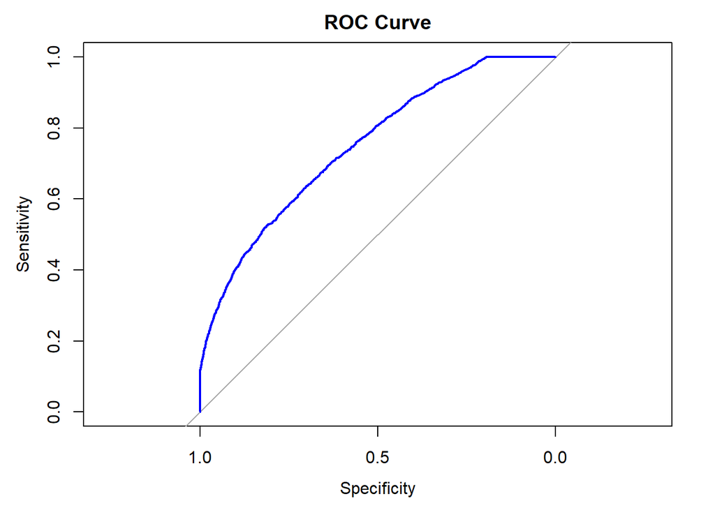

```r
library(pROC)

# ROC Curve
roc_curve <- roc(dfValidation$claimed, preds)
plot(roc_curve, main="ROC Curve", col="blue", lwd=2)
```

```r
# AUC
auc_score <- auc(roc_curve)

print(paste("AUC:", auc_score))
```

```
## [1] "AUC: 0.751127549800116"
```

To understand which features are most important in our model, we analyze the feature importance, focusing on their contribution to the model’s gain. This helps us see which features have the most significant impact on the predictions. I’ve also set up a visual for this so we can talk about the results when we meet.

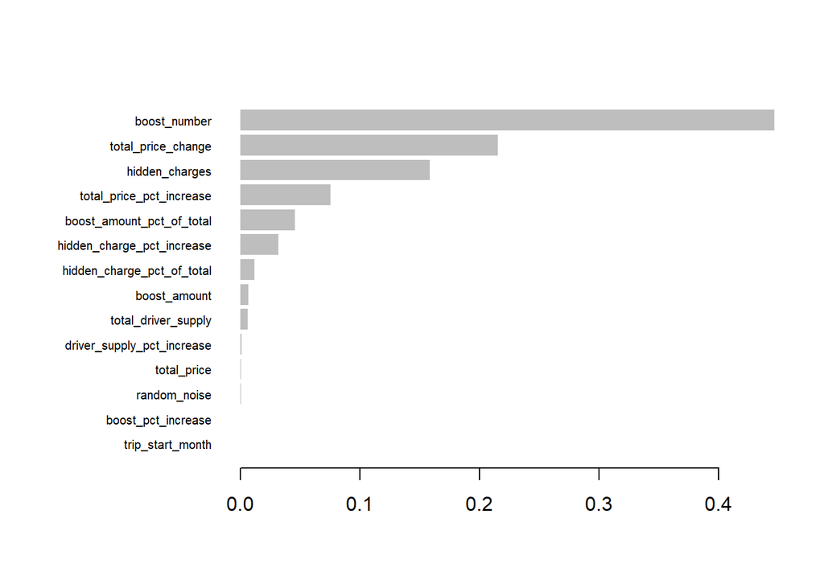

```r
# Assess feature importance
importance_matrix <- xgb.importance(feature_names = colnames(dfTrain %>% select(-claimed)), model = model)
#plot

xgb.plot.importance(importance_matrix, measure = "Gain") # Features listed by Gain
```

Finally, we save the trained model for future use.

```r
# Save the final model
saveRDS(model, "pred_claimed_ride.rds")
```